**Title: Genomic Characterization of Human Cancer Cell Lines as Public Bio Big Data**

# Objectives:

1세대 세포독성 항암제 (cytotoxic chemotherapy)  
2세대 표적치료제 (targeted therapeutics, by means of antibody/and or other physical or chemical targeting technologies incorporated)  
3세대 면역치료제 (immune checkpoint inhibitors -> PD1 or PD-L1 inhibitors, or cell therapy incorporating T-regs)...

However, limitations still remain as the problems of genomic heterogeneity (gh) and clonal evolution (ce) need to be overcome in the path of curing cancer. There are different types of cancer cells in all cancer patients and it is rather difficult as to predict how a specific individual and his/her cancer will react to certain cancer therapeutics. We will learn about how we are able to incorporate publicly released cancer cell line data and drug sensitivity/reactivity data together to explore how tumor-specific somatic mutations and RNA expression profiles will affect the effectivity of each therapeutics in terms of bioinformatics.

[figure not shown]

Figure: Cancer heterogeneity and clonal evolution

1. Introduction
   1. Overview
   2. 실습 준비 및 파일 확인
   3. 유전체 데이터와 약물 감수성의 기본 개념 (genome data and basic concepts of drug sensitivity)
2. COSMIC Cell Line Project (CCLP)
   1. 세포주 다중오믹스 공개 데이터에 접근하기 (Accessing public cell line multi-omics data)
   2. 인간 세포주 데이터 (human cell line data)
   3. sequencing data
   4. gene expression data
3. Genomics of Drug Sensitivity in Cancer (GDSC)
   1. drug sensitivity (or drug intolerance)
   2. CCLE database
   3. Differential expression analysis by drug sensitivity
4. Linking drug sensitivity to omics data
   1. COSMIC CLP and drug sensitivity data (integrative)
   2. exploring/searching for somatic mutations that are associated to drug sensitivity
   3. Drug sensitivity analysis through Differentially Experessed Genes (DEG) data
5. Drug-gene databases
   1. DRUGBANK
   2. PharmGKB
   3. DGIdb
   4. LINCS

References

# Introduction

암세포 박멸을 위한 다양한 항암제가 지금까지 개발되어 왔음.

- 1세대 = cytotoxic drugs
  - 분열하는 암세포를 직접 공격하는 약물로서, 분열이 빠른 암세포가 영향을 크게 받음과 동시에 분화 및 정상적으로 분열해야하는 세포들 까지 영향을 주어 부작용이 매우 크다.
- 2세대 = targeted drugs
  - 1세대에서 조금 나아져서 일반적인 체세포가 아닌 암세포 specific하게 targeting하는 약물이다. 즉, tumor growth에 critical한 요소들을 공격하는 방식으로 암세포를 사멸시킨다. 주로 변이 유전자를 과녁으로 삼으며, 겉으로 드러나는 neoantigen 을 target으로 한다. Lesser side-effects, but the full effects are hard to predict sometimes due to biological variations
- 3세대 = immunotherapeutics

Heterogeneity: 같은 분류의 암환자여도 cell population 내/또는 환자에 따라 모두 다른 체세포 변이 및 다른 특징을 가지고 있다는 뜻. 항암제 처방은 개인맞춤형 치료 방법이 꼭 필요... 그러나 항암제 반응성 예측은 쉽지 않다.

Cancer evolution: 이러한 heterogeneity는 cell evolution에 의해 시간이 지남에 따라 더욱 driven 될 수 있다. 이렇게 특정 cell에게 microenvironment에서의 selective advantage를 주는 mutation을 driver mutation 이라고 한다.

현재는 가이드라인 및 프로토콜에 의해 획일적인 항암제 처방이 이뤄지고 있음. 이 실습에서는 암세포의 분자적인 특성들을 분석하여 암세포 특이적 체세포 돌연변이와 RNA expression level에 따라 어떤 약물이 효과적일지를 연구하는 다양한 바이오정보학 방법론을 학습한다.

COSMIC Cell Line Project (CCLP) 데이터베이스는 약 1,000개의 cell line에 대해 DNA, RNA Expression 등의 다양한 데이터를 통합적으로 제공. 이러한 데이터를 기반으로 다양한 약물실험이 진행되었음. Genomics of Drugs Sensitivity in Cancer (GDSC) 데이터베이스는 265개의 약물에 대한 inhibit concentration 50 (IC50) 값을 CCLP 데이터베이스의 세포주에 적용시켜, 암세포의 돌연변이 및 RNA Expression 같은 분자적 특징과 약물의 반응성을 연결했다.

이번 실습에서는 GDSC database를 활용하여 기존에 알려진 biomarker를 찾아보는 것과 더불어 therapeutics sensitivity에 영향을 미치는 novel biomarker를 찾는 것을 실습하고자 한다.

R programming, GDSC 데이터베이스 제공 데이터 필요. 데이터는 무슨 데이터냐면 - cell line information, somatic mutation, RNA expression, and 세포증식을 50% 억제하는 약제 농도 지표로 약제와 세포주 사이의 반응성을 나타내는 IC50 데이터를 활용.

- 유전체 데이터와 약물 감수성의 기본 개념
  - COSMIC 세포주 (cell line): 실제 암 환자의 암세포를 떼어내고 불멸화하여 (immortalized) 지속적으로 배양 가능한 상태의 세포주 (continuously-grown cell line)로 수립한 다양한 cell line들의 모음이다.
  - 체세포 돌연변이 (somatic mutation): 암 환자의 생식세포가 원래 가진 변이인 Germline variant를 제외하고 암 세포에서만 발견되는 암세포 특이적 변이들.
  - Gene expression: 유전자가 단백질로 얼마나 많이 발현되느냐에 대한 정량적 계측치. 일반적으로 마이크로어레이 (CMA)나 RNA-Seq를 통해 정량한 유전자별 mRNA의 양을 측정한 값에 해당된다.
  - Inhibitory Concentration(IC50): 세포 성장 억제력을 측정하는 지표이다. 암세포주의 성장이 50% 억제되는 약물 농도를 측정한다. 약물별로 그 값이 다르고 서로 다른 약물간의 투약 농도 보정을 위한 값으로 사용한다. 유사한 개념으로 LD50는 50%의 암세포가 죽는 약물의 농도를 말한다. 즉, IC50, LD50 값이 낮을수록, 해당 세포주에 대한 약물의 민감성 (drug sensitivity)는 높다고 할 수 있다.

# COSMIC Cell Line Project (CCLP)

COSMIC = Catalogue Of Somatic Mutations In Cancer

암세포 셀라인에 대한 가장 큰 데이터베이스. 셀라인들의 somatic mutation에 대한 정보를 총합하여 다양한 지식기반 데이터베이스와 API로 연동하여 정보를 제공하기 위한 데이터베이스이다. 암 유전체 연구를 위한 필수 데이터베이스이다.

URL: https://cancer.sanger.ac.uk/cosmic

COSMIC v85, released 08-MAY-18

COSMIC v91, released 07-APR-20

현재 버전은 91이며, 암세포의 차세대 시퀀싱으로 변이를 추출했을 때, 현재까지 발견 된 체세포 돌연변이만 구분해내기 위해 COSMIC 데이터를 활용한다. -> 즉, 기존에 알고있던 somatic mutation을 빼고 de novo (실제 유전학에서 쓰이는 de novo와는 조금 discrepancy가 있는 말이지만)를 가려내기 위해 쓰는 것이다. Cancer Browser, Genome browser 등을 제공하여 조직과 조직병리 등 특정 암과 관련된 변이 및 분석하고자 하는 변이의 특성들을 검색할 수 있다.

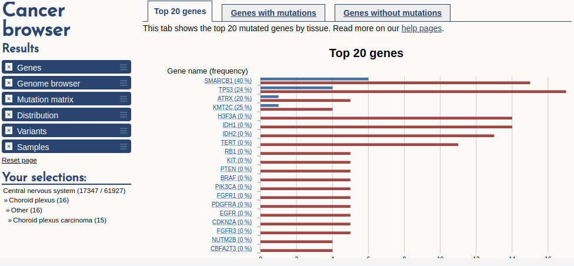

CCLP provides over 1000 cell lines' somatic mutation profiles. CNV and gene expression data are also provided. (somatic mutation, CNV, gene expression profile data -> which makes it multi-omics data) The cell lines are usually the most representative ones used in cancer therapy. And are able to be obtained from ATCC or domestic cell line banks. CCLE, GDSC DBs provide drug sensitivity measurement data with the CCLP provided cell lines.

**CGC** The cancer gene census (CGC) is continuously updated and expanded to classify and include all kinds of somatic mutations that has cauasality with cancer. Over 1% of the entire human genome have to do with mutation in cancer. About 90% of these include somatic mutations in cancer. (not germline mutation) 또한 20%는 암에 걸리기 쉽도록 만드는 germline mutation을 포함한다. 두 분류의 교집합인 10%의 변이는 somatic mutation과 germline mutation이 한꺼번에 일어난다. (One can discover both somatic mutation and germline mutation as contributing factors to cancer.) 현재 719개의 CGC가 제공. Tier1, tier2로 분류. Tier1에 속하는 gene들은 암으로의 transformation을 촉진하는 gene product의 활성이 변화되는 cancer mutation이 논문 등의 문서에서 증거로 제시되는 유전자여야만 한다. -> 즉, literature-backed evidence (source)가 있어야한다. 현재 574개의 유전자가 tier 1으로 지정되어 있다. Tier 2로 분류되기 위해서는 암의 역할에 있어 강한 correlation을 갖는 유전자들이지만, 이용할만한 충분한 증거가 부족한 경우에 해당된다. 현재 145개의 유전자가 tier2로 지정되어 있다. CGC Hallmarks는 전문가에 의해 curation된 정보를 graphical 형태로 보여준다.

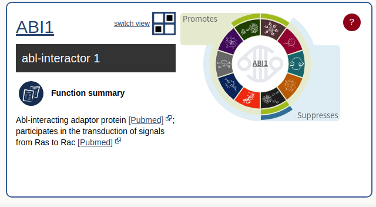

Recessive로 작용하는 대부분은 tumor suppressor gene이다. Dominant로 작용하는 암 유전자들은 fusion gene 등의 rearrangement를 포함하는 경우, 혹은 oncogene인 경우가 대부분이다. 2개 이상의 역할을 하는 유전자들도 존재한다. 각 암종별로 중요한 암 유전자들은 COSMIC에서 제공하는 이 CGC 유전자 목록을 참조하면 된다.

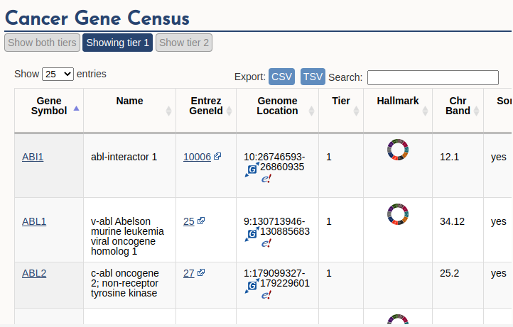

## 세포주 다중오믹스 공개 데이터 접근하기

Download: https://cancer.sanger.ac.uk/cosmic/download

사이트에 가입 후, academic user로 license confirm만 받으면 직접 다운 가능. 정제된 데이터 제공하므로 용량이 작아서 windows PC에서도 이용가능. (GB 이하 단위) CCLP 데이터는 학술적/비영리적 목적으로 자유롭게 이용할 수 있음. 하지만 상업적 및 영리적 목적으로는 새로운 라이센스를 얻어야함. E-mail confirmation만 하면 academic user로서 이용 가능. 이번 실습에서는 세포주의 **classification**, **mutation profile**, **gene expression** 세가지 데이터를 이용한다.

## 인간 세포주 데이터

COSMIC은 염기서열 분석 데이터 (somatic mutation) 및 expression data를 제공하는 세포주의 목록과 특성이 들어있는 Samples_detail.txt 파일을 제공한다. Column이 많아서 중요한 데이터만 추출하여 표시.

Cell lines: Cell line bank에서 사용하는 공식 명칭

COSMIC_ID: 숫자로 된 ID

Tissue 1과 tissue 2의 데이터 제공. (tissue 2가 더 상세한 위치를 가리킴.)

TCGA: 진단된 암의 이름을 뜻함. 암종의 이름을 약자로 표기해놓은 것이다. 그 중 LUAD의 경우 Lung adenocarcinoma. [여기](https://gdc.cancer.gov/resources-tcga-users/tcga-code-tables/tcga-study-abbreviations)로 가면 더 상세한 테이블을 볼 수 있다.

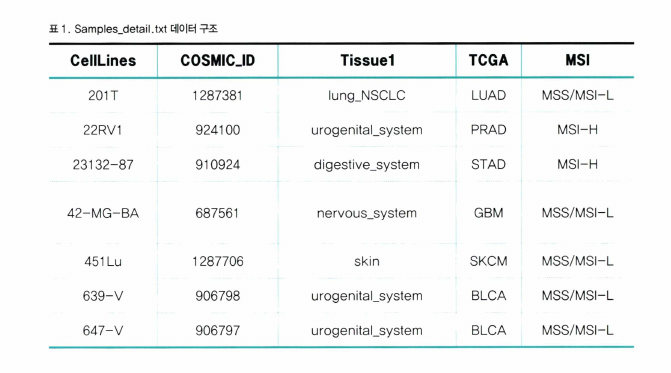

## 염기서열 시퀀싱 데이터 (sequencing data)

일반적으로 시퀀싱 자료는 raw data (원시자료)의 처리 과정을 거쳐 variant calling pipeline에 의해 vcf 파일 포맷으로 저장된다. VCF파일에서 시작하여 데이터 전처리를 수행하는 것은 실습의 범위를 넘어서므로 다음과 같이 이진행렬로 구성된 데이터를 제공한다.

(표 Mutated Matrix.txt)

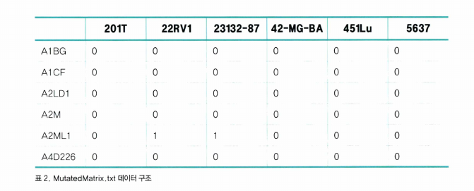

실습 데이터는 CNA (Copy Number Alteration/variation) 데이터와 somatic mutation 파일 둘을 합쳐서 구성했다. 각 데이터는 아래 조건에 따라 추출했다.

- SureSelectXT Human ALl Exon 50Mb, Affymetrix SNP6 array
  - Exon에 대한 CMA?
  - Variant calling: [Caveman](https://currentprotocols.onlinelibrary.wiley.com/doi/abs/10.1002/cpbi.20) for Somatic Single Nucleotide Variants, [Pindel](https://academic.oup.com/bioinformatics/article/25/21/2865/2112044) algorithm for detection of detect break points of large deletions and medium sized insertions from paired-end short reads.
  - Copy number estimation: [PICNIC](https://www.ncbi.nlm.nih.gov/pmc/articles/PMC2800165/) algorithm, which is an HMM-based algorithm for estimating copy number variation.
- Germline filter
  - Read depth => 15
  - Mutant allele burden => 15%
  - Variant not seen at any level in the reference normal samples
- Confidence filter
  - 1000 genomes (Mar 29th 2012 release) - variants with a frequency > 0.0014 have been removed. (Not rare)
  - ESP6500 - variants with a frequency >= 0.0025 have been removed.
  - DBSNP - SNPs that have a minor allele frequency have been removed.
  - In-house normal set (n=350) - variants seen in more than 1 normal have been removed.

**Build binary disruption matrix of significantly altered genes** The algorith uses somatic mutations and copy number evengts across all observed samples applied multiple gene filters.

1 if gene i is altered by a missense somatic mutation SIFT < 0.05 in sample j;  
1 if gene i is altered by a loss of function mutation  
1 if gene i is homozygously deleted in sample j  
0 otherwise

이 세가지 조건을 만족하는 변이를 가진 유전자를 altered gene으로 선정. SIFT (sorting intolerant from tolerant) 알고리듬으로 coding region의 evolutionary conservedness를 평가하는 알고리즘 중 하나로, 0~1 사이 값을 가지며 0에 가까울수록 변이의 위해도가 크다는 것을 의미.

Somatic mutation

- Missense mutation: changed amino acid
- Synonymous mutation: no change
- Nonsense mutation: stop codon, trunctation/stop translation
- Splice site mutation: Alternative splicing에 영향
- Frameshift mutation: InDel에 의하여 open reading frame에 변이가 생기는 경우.

Nonsense mutation, splice site mutation, frameshift mutation, Copy number alteration 중 homozygous deletion (loss of both alleles)이 있는 경우와 같이 아얘 loss of function을 유발할 것으로 예측되는 변이를 LoF (loss of function)이라고 한다.

SIFT score 0.05 or less, CADD 점수 20 or more 인 경우 LoF에 준하는 변이로 해석한다.

LoF 평가 결과에 따라 LoF변이 포함 유전자는 1, 정상유전자는 0으로 표기한 binary matrix가 `MutatedMatrix.txt`이다. 이 데이터를 이용하여 항암제의 반응성, LoF간의 관계를 분석할 것이다.

## 유전체 발현 데이터

Microarray 데이터는 cDNA와 probe-target hybridization을 활용하여 유전자의 발현량을 빛의 intensity로 측정하는 기술이다. 이미 z-scale로 normalization이 끝난 데이터를 제공하므로 up-stream analysis를 수행하지 않아도 바로 분석에 활용할 수 있다. https://www.codecademy.com/articles/normalization

z-score normalization은 outlier가 있을 때, x-axis와 y-axis scale간의 차이를 줄여주어 outlier를 제대로 detect할 수 있게 해준다.

$$\frac{\rm{value}-\mu}{\sigma}$$

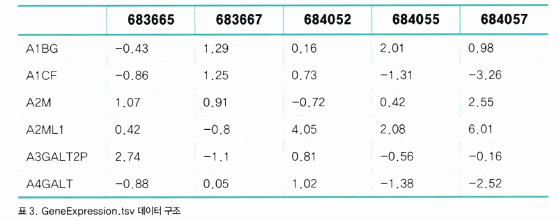

유전자 발현량은 뭐 시점에 따라 변하지만, population of cell에 대하여 계측한 것이므로 해당 종양의 cross sectional average로 가정하고 분석한다. mRNA expression data는 발암유전자 (oncogene)의 과발현을 쉽게 확인할 수 있어 항암제 반응성 예측에 좋은 도구이다. Oncotype DX와 MammaPrint는 유방암에서 microarray data로 recurrence 위험도를 예측하는 대표적인 알고리즘이다. 이 실습에서 Random forest 모델로 항암제 반응성 예측 모형을 만들어 본다.

# Genomics of Drug Sensitivity in Cancer (GDSC)

COSMIC Cell Line Project (CCLP) database에 존재하는 cell line들에 대해 항암제를 투여하여 drug sensitivity를 측정한 결과물을 담고 있다. CCLE도 같은 concept의 study로 GDSD보다 먼저 발표되었지만 적은 양의 데이터가 포함되어 있다. GDSC는 총 265개의 약물과 1,001개의 세포주 데이터를 제공한다.

Database url: https://www.cancerrxgene.org/

IC50, AUC에 대한 정보가 있다. AUC는 area under curve의 약자로서, ROC 곡선 아래의 면적을 나타내며, ROC curve는 true positive와 false positive rate이 늘어나는 정도를 곡선으로 나타낸 것이다. 즉 실제와 가짜 signal을 얼마나 잘 구분해 내느냐의 척도이다. 0.5 이상이어야 하며, 위로 휘어야 한다. https://towardsdatascience.com/understanding-auc-roc-curve-68b2303cc9c5

- Compound
  - 약물을 중점적으로. 266개의 약물을 리스트로 볼 수 있음.
  - 이름, target, target pathway 정보, PucCHEM ID, IC50, sample size

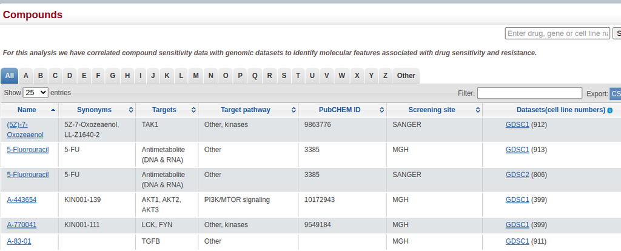

  Gefitinib 같은 경우 EGFR을 타겟으로 하며, 폐암 환자 중 EGFR 돌연변이를 가진 환자들에게 EGFR-TKI (tyrosin kinase inhibitor)를 쓰는 것이 잘 확립된 임상 사례이다. 실제 급여로 인정됨.

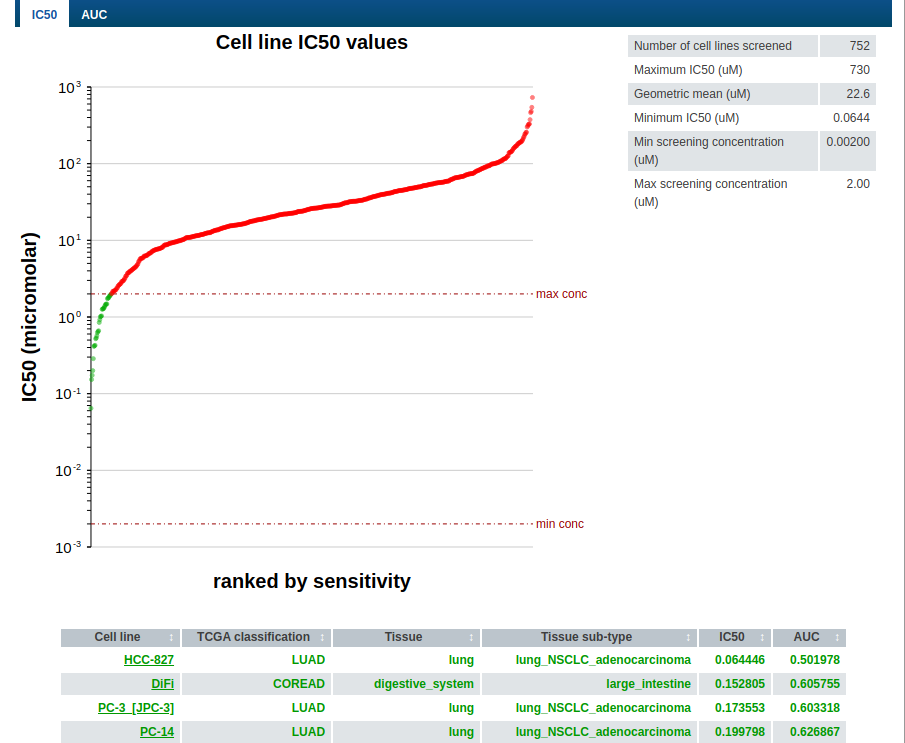

  Clinical feature에서 EGFR을 선택했을 때, 항암제의 반응성. y축이 reverse된 log10 (p-value)로 유의도를 나타내고, x축이 IC50, 즉 민감도를 나타낸다.

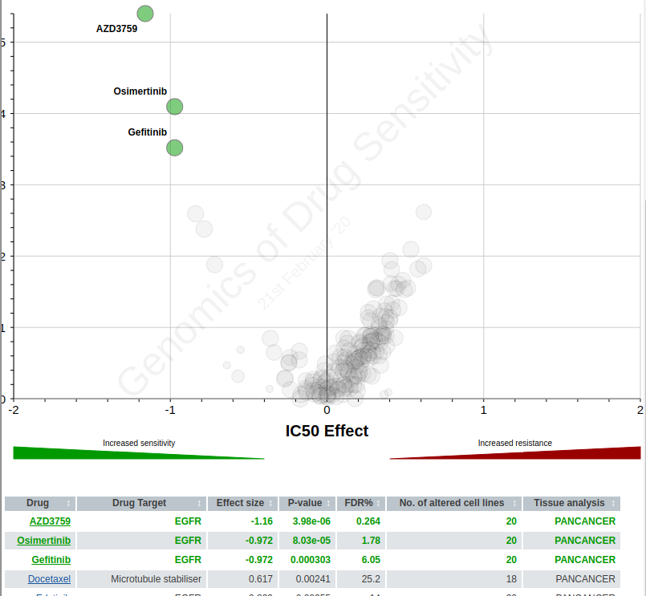

  ## IC50, EC50

  ## CCLE (cancer cell line encylopedia)

  Multi-omics + epigenetics profile + pharmacological profiles -> comparable to GDSC

  Drug sensitivity를 측정하기 위한 IC50 측정 방식이 시계열 방식이라서 조금 차이는 있으나 GDSC와 일관된 결과를 보임.

# Linking drug sensitivity to omics data

## COSMIC CCLP and Drug sensitivity data

COSMIC CCLP 세포주 데이터를 R로 분석. 세포주는 어떤 부위에서 추출된 세포인지, 암의 진단명은 무엇인지 통계분포를 얻을 수 있음.

```python
%load_ext rpy2.ipython
```

```python
%%R
getwd()
```

```
[1] "/home/seungho/GDA/PublicCelllines/homework"
```

```python
%%R
library(ggplot2)
library(reshape2)
Samples <- read.csv("~/GDA/PublicCelllines/Samples_detail.txt", header=T, stringsAsFactors=F, sep="\t")
```

```python
%%R
Samples
```

```
              CellLines COSMIC_ID           Tissue1
1                  A253    906794    aero_dig_tract
2              BB30-HNC    753531    aero_dig_tract
3              BB49-HNC    753532    aero_dig_tract
4                   BHY    753535    aero_dig_tract
5                BICR10   1290724    aero_dig_tract
6                BICR22   1240121    aero_dig_tract
7                BICR31   1290725    aero_dig_tract
8                BICR78   1240122    aero_dig_tract
9                Ca9-22    753538    aero_dig_tract
10               CAL-27    910916    aero_dig_tract
11               CAL-33    753541    aero_dig_tract
12           Detroit562    906837    aero_dig_tract
13                  DOK    910936    aero_dig_tract
14                 FADU    906863    aero_dig_tract
```

[output cut: 735 more lines]

[output not shown]

```
                    B_cell_lymphoma               DLBC MSS/MSI-L        R
129                     B_cell_lymphoma               DLBC MSS/MSI-L        R
130                     B_cell_lymphoma               DLBC MSS/MSI-L        R
131                     B_cell_lymphoma               DLBC MSS/MSI-L    D/F12
132                     B_cell_lymphoma               DLBC MSS/MSI-L        R
133                     B_cell_lymphoma               DLBC MSS/MSI-L        R
134                     B_cell_lymphoma               DLBC MSS/MSI-L        R
135                     B_cell_lymphoma               DLBC MSS/MSI-L        R
136                     B_cell_lymphoma               DLBC MSS/MSI-L        R
137                     B_cell_lymphoma               DLBC MSS/MSI-L        R
138                     B_cell_lymphoma               DLBC MSS/MSI-L        R
139                     B_cell_lymphoma               DLBC MSS/MSI-L        R
140                     B_cell_lymphoma               DLBC MSS/MSI-L        R
141                     B_cell_lymphoma               DLBC MSS/MSI-L        R
142                     B_cell_lymphoma               DLBC MSS/MSI-L        R
```

[output cut: 586 more lines]

[output not shown]

```
      Adherent
540       Adherent
541       Adherent
542       Adherent
543       Adherent
544       Adherent
545       Adherent
546       Adherent
547       Adherent
548       Adherent
549       Adherent
550       Adherent
551       Adherent
552     Suspension
553       Adherent
```

[output cut: 448 more lines]

```python
%%R
dim(Samples) #Row: 1001 cell lines
```

```
[1] 1001    8
```

```python
%%R
Tissue <- table(Samples$Tissue1) # frequency table을 만든다.
par(mar = c(10, 3, 3, 3)) #margin: bottom, left, top, right
barplot(Tissue, col = rainbow(19), las=2) # frequency table인 Tissue를 인자로 받고, 색,
                                        # label은 perpendicular to x-axis
```

[figure not shown]

```python
%%R
Tissue
```

```
   aero_dig_tract              bone            breast  digestive_system
               79                40                52                52
           kidney   large_intestine          leukemia              lung
               34                51                85                22
       lung_NSCLC         lung_SCLC          lymphoma           myeloma
              111                66                70                18
   nervous_system     neuroblastoma          pancreas              skin
               57                32                32                58
      soft_tissue           thyroid urogenital_system
               21                16               105
```

```python
%%R

# Tissue에 따른 샘플의 분포

DF_tissue <- data.frame(Tissue) #table을 data frame으로 바꾼다.
colnames(DF_tissue) <- c("Tissue", "Freq") #DF_tissue의 column name들을 labeling한다.

p <- ggplot(DF_tissue, aes(x=Tissue, y=Freq, fill=Tissue)) +
    geom_bar(stat="identity")

p <- p + theme(axis.text.x = element_text(angle = -30, hjust = 0))
print(p)

tiff("01.figure_OrganDistribution.tif", res=130, height=800, width=1200)


dev.off() # close the plotting device
```

[figure not shown]

```python
%%R
rlang::last_error()
```

[output not shown]

Cancer type에 따른 샘플의 분포

```python
%%R
TCGA <- table(Samples$TCGA)
DF_TCGA <- data.frame(TCGA)
colnames(DF_TCGA) <- c("TCGA", "Freq")
p <- ggplot(DF_TCGA, aes(x=TCGA, y=Freq, fill=TCGA))+geom_bar(stat="identity")
p <- p + theme(axis.text.x = element_text(angle = -30, hjust = 0))
p <- p + geom_text(data=DF_TCGA, aes(TCGA, Freq, label=Freq),
                   position = position_dodge(width=0.9))

print(p)

tiff("02.figure_CancerType.tif", res = 130, height = 800, width = 1800)

dev.off()
```

[figure not shown]

세포주들의 특성이 다양한 만큼, 데이터가 확보되는 일부 암종 외에는 통계분석에 있어 유의미한 값을 얻기 힘들다.

Drug information 데이터

```python
%%R
Drugs <- read.csv("~/GDA/PublicCelllines/DrugInfo.tsv", header=T,
                 stringsAsFactors=F, sep="\t")

print(head(Drugs))
print(Drugs[ Drugs$TARGET_PATHWAY == "Mitosis", -3])
print(Drugs[ Drugs$TARGET_PATHWAY == "DNA replication", -3])
```

```
  DRUG_ID  DRUG_NAME                                                SYNONYMS
1       1  Erlotinib Tarceva, RG-1415, CP-358774, OSI-774, Ro-508231, R-1415
2       3  Rapamycin       AY-22989, Sirolimus, WY-090217, Torisel, Rapamune
3       5  Sunitinib                      Sutent, Sunitinib Malate, SU-11248
4       6 PHA-665752                                   PHA665752, PHA 665752
5       9     MG-132                                  LLL cpd, MG 132, MG132
6      11 Paclitaxel   BMS-181339-01, Taxol, Onxol, Paxene, Praxel, Abraxane
                               TARGET                    TARGET_PATHWAY
1                                EGFR                    EGFR signaling
2                              MTORC1               PI3K/MTOR signaling
3 PDGFR, KIT, VEGFR, FLT3, RET, CSF1R                     RTK signaling
4                                 MET                     RTK signaling
5                   Proteasome, CAPN1 Protein stability and degradation
6              Microtubule stabiliser                           Mitosis
    DRUG_ID           DRUG_NAME                      TARGET TARGET_PATHWAY
```

[output cut: 25 more lines]

## 약물 민감성과 유의하게 연관된 돌연변이 탐색

IC50 데이터의 전처리

```python
%%R
GDSC <- read.csv("~/GDA/PublicCelllines/DoseResponse.txt", header = T, sep = '\t')
dim(GDSC)
head(GDSC, 5)
```

```
  DATASET_VERSION IC50_RESULTS_ID COSMIC_ID DRUG_ID MAX_CONC_MICROMOLAR
1              17             335    924100    1026                 1.0
2              17             336    924100    1028                 2.0
3              17             337    924100    1029                 2.0
4              17             338    924100    1030                10.0
5              17             339    924100    1031                 0.2
     LN_IC50       AUC       RMSE
1  0.7177216 0.8994101 0.10566534
2  2.6640996 0.9572059 0.17824333
3  3.3368284 0.9738928 0.07984536
4  5.1649088 0.9778440 0.09422821
5 -4.3253093 0.5081798 0.09047776
```

GDSC를 AUC와 IC50에 대한 array로 preprocessing

```python
%%R

AUC <- acast(GDSC, COSMIC_ID~DRUG_ID, value.var = "AUC",
            fun.aggregate = mean)
IC50 <- acast(GDSC, COSMIC_ID~DRUG_ID, value.var = "LN_IC50",
              fun.aggregate = mean)
```

```python
%%R
print(head(AUC, 3))
print(head(IC50, 3))
```

```
               1         3         5         6         9      11        17
683665 0.9824841 0.9812138 0.9036151 0.9865131 0.9368529 0.72757 0.9783909
683667       NaN       NaN       NaN       NaN       NaN     NaN       NaN
684052       NaN       NaN       NaN       NaN       NaN     NaN       NaN
              29        30        32        34        35        37        38
683665 0.9449438 0.9885379 0.8969033 0.9893166 0.9879371 0.9894152 0.9888408
683667       NaN       NaN       NaN       NaN       NaN       NaN       NaN
684052       NaN       NaN       NaN       NaN       NaN       NaN       NaN
             41        45        51        52        53       54        55
683665 0.733993 0.7484016 0.9153892 0.9892711 0.6990281 0.929197 0.7948666
683667      NaN       NaN       NaN       NaN       NaN      NaN       NaN
684052      NaN       NaN       NaN       NaN       NaN      NaN       NaN
             56        59        60        62        63        64        71
683665 0.951566 0.9876495 0.8443911 0.9079936 0.9631236 0.8250296 0.9886793
683667      NaN       NaN       NaN       NaN       NaN       NaN       NaN
```

[output cut: 289 more lines]

```python
%%R
AUC[1:5, 1:5]
```

```
               1         3         5         6         9
683665 0.9824841 0.9812138 0.9036151 0.9865131 0.9368529
683667       NaN       NaN       NaN       NaN       NaN
684052       NaN       NaN       NaN       NaN       NaN
684055 0.9849859 0.9811678 0.9399154 0.9813849 0.9552497
684057 0.9829394 0.9828317 0.9341512 0.9635094 0.9195831
```

```python
%%R
#IC50, AUC에 rowname, colname을 samples의 COSMIC_ID 와 drugs의 DURG_NAME으로 부터 넣어준다.
idx <- match(rownames(IC50), Samples$COSMIC_ID)
rownames(IC50) <- Samples[idx, "CellLines"]
rownames(AUC) <- Samples[idx, "CellLines"]

idx <- match(colnames(IC50), Drugs$DRUG_ID)
colnames(IC50) <- Drugs[idx, "DRUG_NAME"]
colnames(AUC) <- Drugs[idx,"DRUG_NAME"]
```

```python
%%R
print(IC50[1:5, 1:3])
print(AUC[1:5, 1:3])
```

```
       Erlotinib   Rapamycin Sunitinib
MC-CAR  2.436586 -0.62114953  2.167218
PFSK-1       NaN         NaN       NaN
A673         NaN         NaN       NaN
ES3     3.342826  0.09599503  3.128074
ES5     3.571787  0.56839320  3.237325
       Erlotinib Rapamycin Sunitinib
MC-CAR 0.9824841 0.9812138 0.9036151
PFSK-1       NaN       NaN       NaN
A673         NaN       NaN       NaN
ES3    0.9849859 0.9811678 0.9399154
ES5    0.9829394 0.9828317 0.9341512
```

Drug sensitivity 데이터와 분석할 cell line의 유전체 데이터를 불러온다. 유전자별로 binary matrix로 구성된 somatic mutation and gene expression information을 load한다. 이후 IC50, somatic mutation, expression 세가지 데이터가 모두 존재하는 세포주만 분석에 활용.

```python
%%R
Mutation <- read.csv("../MutatedMatrix.txt", sep="", check.names=FALSE)
Expression <- read.csv("../GeneExpression.tsv", sep="", check.names=FALSE)

Names <- intersect(colnames(Mutation), colnames(Expression))
Names <- intersect(Names, rownames(IC50))
```

```python
%%R
idx_Mut <- match(Names, colnames(Mutation))
idx_Exp <- match(Names, colnames(Expression))
idx_IC50 <- match(Names, rownames(IC50))
idx_Sams <- match(Names, Samples$CellLines)

Mutation <- Mutation[, idx_Mut]
Expression <- Expression[, idx_Exp]
IC50 <- IC50[idx_IC50, ]
TissueType <- factor(Samples$Tissue1[idx_Sams])

Mutation <- as.matrix(Mutation)
Expression <- as.matrix(Expression)
```

```python
%%R
res <- lm(IC50[,"Afatinib"]~Mutation["EGFR",])
summary(res)
```

```
Call:
lm(formula = IC50[, "Afatinib"] ~ Mutation["EGFR", ])

Residuals:
    Min      1Q  Median      3Q     Max
-7.5590 -0.5514  0.4277  0.9657  2.8013

Coefficients:
                   Estimate Std. Error t value Pr(>|t|)
(Intercept)         0.86143    0.05261  16.373   <2e-16 ***
Mutation["EGFR", ] -0.36682    0.23530  -1.559    0.119
---
Signif. codes:  0 ‘***’ 0.001 ‘**’ 0.01 ‘*’ 0.05 ‘.’ 0.1 ‘ ’ 1

Residual standard error: 1.468 on 818 degrees of freedom
  (129 observations deleted due to missingness)
Multiple R-squared:  0.002962,	Adjusted R-squared:  0.001743
F-statistic:  2.43 on 1 and 818 DF,  p-value: 0.1194
```

```python
%%R
res <- lm(IC50[,"Afatinib"]~Mutation["EGFR",]+TissueType)
summary(res)
```

```
Call:
lm(formula = IC50[, "Afatinib"] ~ Mutation["EGFR", ] + TissueType)

Residuals:
    Min      1Q  Median      3Q     Max
-7.2985 -0.6210  0.1824  0.7909  3.7031

Coefficients:
                            Estimate Std. Error t value Pr(>|t|)
(Intercept)                  -1.0760     0.1609  -6.687 4.27e-11 ***
Mutation["EGFR", ]           -0.3880     0.2128  -1.823   0.0686 .
TissueTypebone                2.5789     0.2778   9.283  < 2e-16 ***
TissueTypebreast              1.4620     0.2536   5.765 1.17e-08 ***
TissueTypedigestive_system    2.0266     0.2612   7.759 2.61e-14 ***
TissueTypekidney              1.2842     0.3063   4.193 3.06e-05 ***
TissueTypelarge_intestine     1.8575     0.2597   7.151 1.94e-12 ***
TissueTypeleukemia            2.1891     0.2217   9.873  < 2e-16 ***
TissueTypelung                2.6714     0.3633   7.353 4.80e-13 ***
TissueTypelung_NSCLC          1.6982     0.2117   8.022 3.69e-15 ***
TissueTypelung_SCLC           2.6949     0.2431  11.086  < 2e-16 ***
TissueTypelymphoma            2.2827     0.2315   9.860  < 2e-16 ***
TissueTypemyeloma             2.3840     0.3466   6.877 1.23e-11 ***
TissueTypenervous_system      2.7286     0.2443  11.168  < 2e-16 ***
TissueTypeneuroblastoma       2.5415     0.2979   8.530  < 2e-16 ***
TissueTypepancreas            2.0260     0.3020   6.709 3.71e-11 ***
TissueTypeskin                2.4131     0.2472   9.762  < 2e-16 ***
TissueTypesoft_tissue         2.3704     0.3834   6.182 1.01e-09 ***
TissueTypethyroid             2.4178     0.4089   5.912 4.99e-09 ***
TissueTypeurogenital_system   1.6486     0.2136   7.718 3.53e-14 ***
---
Signif. codes:  0 ‘***’ 0.001 ‘**’ 0.01 ‘*’ 0.05 ‘.’ 0.1 ‘ ’ 1

Residual standard error: 1.303 on 800 degrees of freedom
  (129 observations deleted due to missingness)
Multiple R-squared:  0.2323,	Adjusted R-squared:  0.2141
F-statistic: 12.74 on 19 and 800 DF,  p-value: < 2.2e-16
```

```python
%%R
res <- lm(IC50[,"Gefitinib"]~Mutation["EGFR",])
summary(res)
res <- lm(IC50[,"Gefitinib"]~Mutation["EGFR",]+TissueType)
summary(res)
```

```
Call:
lm(formula = IC50[, "Gefitinib"] ~ Mutation["EGFR", ] + TissueType)

Residuals:
    Min      1Q  Median      3Q     Max
-4.8463 -0.5358  0.0899  0.6503  2.5980

Coefficients:
                            Estimate Std. Error t value Pr(>|t|)
(Intercept)                  -0.3158     0.1219  -2.592 0.009723 **
Mutation["EGFR", ]           -0.5808     0.1612  -3.603 0.000334 ***
TissueTypebone                1.8352     0.2104   8.724  < 2e-16 ***
TissueTypebreast              1.7867     0.1921   9.303  < 2e-16 ***
TissueTypedigestive_system    1.4492     0.1978   7.326 5.80e-13 ***
TissueTypekidney              1.0890     0.2319   4.695 3.13e-06 ***
TissueTypelarge_intestine     1.7016     0.1983   8.583  < 2e-16 ***
TissueTypeleukemia            1.2688     0.1674   7.582 9.50e-14 ***
TissueTypelung                2.0101     0.2751   7.306 6.71e-13 ***
TissueTypelung_NSCLC          1.3201     0.1599   8.254 6.32e-16 ***
TissueTypelung_SCLC           1.8555     0.1841  10.079  < 2e-16 ***
TissueTypelymphoma            1.2989     0.1753   7.409 3.25e-13 ***
TissueTypemyeloma             1.3817     0.2625   5.263 1.82e-07 ***
TissueTypenervous_system      1.9166     0.1850  10.358  < 2e-16 ***
TissueTypeneuroblastoma       1.4614     0.2287   6.390 2.81e-10 ***
TissueTypepancreas            1.7593     0.2287   7.693 4.24e-14 ***
TissueTypeskin                1.7048     0.1884   9.051  < 2e-16 ***
TissueTypesoft_tissue         1.7494     0.2994   5.842 7.50e-09 ***
TissueTypethyroid             1.7701     0.3097   5.716 1.54e-08 ***
TissueTypeurogenital_system   1.2738     0.1622   7.854 1.30e-14 ***
---
Signif. codes:  0 ‘***’ 0.001 ‘**’ 0.01 ‘*’ 0.05 ‘.’ 0.1 ‘ ’ 1

Residual standard error: 0.9868 on 797 degrees of freedom
  (132 observations deleted due to missingness)
Multiple R-squared:  0.2101,	Adjusted R-squared:  0.1913
F-statistic: 11.16 on 19 and 797 DF,  p-value: < 2.2e-16
```

```python
%%R
DF <- data.frame(Sensitivity = IC50[,"Afatinib"],
                EGFR = factor(Mutation["EGFR",]), TissueType)
p=ggplot(DF, aes(x=EGFR, y=Sensitivity, fill=EGFR)) + geom_boxplot() +
facet_wrap(~TissueType, nrow=4)

print(p)

tiff("03.figure_Afatinib_mutation.tif", res=130, height=800, width=1800)

dev.off()
```

[figure not shown]

```python
%%R
DF <- data.frame(Sensitivity = IC50[,"Gefitinib"],
                EGFR = factor(Mutation["EGFR",]), TissueType)
p=ggplot(DF, aes(x=EGFR, y=Sensitivity, fill=EGFR)) + geom_boxplot() +
facet_wrap(~TissueType, nrow=4)

print(p)

tiff("04.figure_Gefitinibib_mutation.tif", res=130, height=800, width=1800)

dev.off()
```

[figure not shown]

```python
%%R
idx_Lung <- grepl("lung", TissueType)
res <- lm(Sensitivity ~ EGFR, data=DF[idx_Lung,])
summary(res)
```

```
Call:
lm(formula = Sensitivity ~ EGFR, data = DF[idx_Lung, ])

Residuals:
    Min      1Q  Median      3Q     Max
-3.7160 -0.5025  0.1714  0.7050  3.3290

Coefficients:
            Estimate Std. Error t value Pr(>|t|)
(Intercept)  1.29374    0.08612  15.022  < 2e-16 ***
EGFR1       -2.00044    0.48259  -4.145 5.57e-05 ***
---
Signif. codes:  0 ‘***’ 0.001 ‘**’ 0.01 ‘*’ 0.05 ‘.’ 0.1 ‘ ’ 1

Residual standard error: 1.062 on 155 degrees of freedom
  (33 observations deleted due to missingness)
Multiple R-squared:  0.09979,	Adjusted R-squared:  0.09399
F-statistic: 17.18 on 1 and 155 DF,  p-value: 5.571e-05
```

## 차별발현 유전자 (DEG) 데이터를 이용한 약물 민감성 분석

```python
%%R
DF <- data.frame(ERBB2 = Expression["ERBB2",], TissueType)
p <- ggplot(DF, aes(x=TissueType, y = ERBB2, fill=TissueType))
p <- p + geom_boxplot() + ggtitle("ERBB2 expression")
p <- p + theme(axis.text.x = element_text(angle = -30, hjust = 0))

print(p)

tiff("05.figure_ERBB2_Expression.tif", res=130, height=800, width=1200)

dev.off()
```

[figure not shown]

Breast cancer에서 유독 ERBB2 발현량이 높다.

```python
%%R

idx_BRCA <- which(TissueType=="breast")
DF <- data.frame(ERBB2 = Expression["ERBB2", idx_BRCA],
                Afatinib = IC50[idx_BRCA, "Afatinib"])

p = ggplot(DF, aes(ERBB2, Afatinib)) + geom_point() + geom_smooth(method'lm', se=TRUE)

print(p)

tiff("06.figure_ERBB2_Afatinib.tif", res=130, height=800, width=1000)

dev.off()
```

[output not shown]

[output cut: 9 more lines]

[output not shown]

```python
%%R
idx_BRCA <- which(TissueType == "breast")
idx_BRCA
```

```
 [1]  42  63  64  65  66  78  80  85  90  91 122 175 186 187 211 277 278 279 280
[20] 281 282 283 284 285 286 287 288 289 290 292 293 299 332 368 478 479 480 481
[39] 482 483 484 485 486 498 523 677 885 924 925 946
```

```python
%%R
DF <- data.frame(ERBB2 = Expression["ERBB2", idx_BRCA],
                Afatinib = IC50[idx_BRCA, "Afatinib"])
```

```python
%%R
p = ggplot(DF, aes(ERBB2, Afatinib)) + geom_point() + geom_smooth(method = 'lm', se= TRUE)
```

```python
%%R
print(p)
tiff("06.figure_ERBB2_Afatinib.tif", res = 130, height = 800, width = 1000)

dev.off()
```

```
R[write to console]: `geom_smooth()` using formula 'y ~ x'
```

[figure not shown]

```python
%%R
cors <- c()
for (i in 1:nrow(Expression)){
    cors[i] <- cor.test(IC50[idx_BRCA, "Afatinib"],
                       Expression[i, idx_BRCA])$estimate
}
summary(cors)
```

```
    Min.  1st Qu.   Median     Mean  3rd Qu.     Max.
-0.64277 -0.17705 -0.04455 -0.04222  0.09019  0.66608
```

```python
%%R
DF <- data.frame(ERBB2 = Expression["EGFR",],
                Afatinib = IC50[,"Afatinib"], TissueType)
p = ggplot(DF,aes(ERBB2, Afatinib)) + geom_point() + facet_wrap(~TissueType,ncol=5) +
geom_smooth(method='lm', se=TRUE)

print(p)

tiff("07.figure_EGFR_Afatinib.tif", res=130, height=800, width=1000)

dev.off()
```

```
R[write to console]: `geom_smooth()` using formula 'y ~ x'
```

[figure not shown]

Tissue type에 따른 EGFR 발현량과 Afatinib의 관계

EGFR의 발현량이 증가할 때, Non-small cell Lung cancer에서는 Afatinib의 민감도가 증가하는 것을 볼 수 있다. 기존에 EGFR 돌연변이를 분석한 그림에서와 일관된 결과를 보이는 것을 확인할 수 있다.

```python
%%R
DF <- data.frame(Exp = Expression["EGFR", idx_Lung],
                Mut = factor(Mutation["EGFR", idx_Lung]))

p = ggplot(DF, aes(x=Mut, y=Exp, fill=Mut)) + geom_boxplot() +
ggtitle("EGFR expression ~ Mutation")

print(p)

tiff("08.figure_EGFR_ExpMut.tif", res=130, height=500, width=500)

dev.off()
```

[figure not shown]

EGFR 유전자 돌연변이가 있는 경우, EGFT의 mRNA 발현량이 올라가는 패턴을 확인할 수 있다. 즉, EGFR 변이가 Gain of Function (GoF)를 일으켜 mRNA 발현량이 올라가는 것이며, Afatinib이 이를 suppression하는 것을 추론할 수 있다

DRUGBANK 데이터베이스에서 Afinib을 검색하면, 타겟 단백질에 EGFR과 ERBB2가 있음을 확인할 수 있다. 즉 두 단백질과 Afatinib은 Drug와 target으로 작용하는 직접적인 protein-ligand docking을 통해 EGFR과 ERBB2가 억제됨을 알 수 있다.

# Drug-gene databases

## DRUGBANK

url: https://www.drugbank.ca

DRUGBANK는 생물정보학적으로 다양한 참조를 얻을 수 있는 약물 데이터베이스이다. 약물 이름으로 검색하면 언제 사용하는 약물이며 퇴출되었는지, 승인되었는지 등의 기본적인 정보부터 시작하여 어떤 용량으로 만들어지는지, protein-drug interaction등의 다양한 내용에 대한 상세한 설명이 제공된다.

[figure not shown]

이 데이터베이스에서 가장 재미있게 볼 수 있는 정보는 바로 Drug-gene interaction이다. DRUGBANK는 유전자 약물 상호작용을 target, transporter, carrier, 그리고 enzyme 네가지로 분류한다.

1. Target: 주어진 약물이 protein, macromolecule, mucleic acid, small molecule 등과 binding하여 해당 물질이 정상적인 기능을 못하도록 막는 방법으로 치료 효과를 발생시키는 것. 이러한 target물질은 주로 enzyme이나 ion channels, receptor등과 같은 단백질들이다.
2. Enzyme: 주어진 약물을 기질로하여 화학반응을 촉매하는 단백질들을 의미한다.
3. Transporter: 세포막을 가로질러 이온, 작은 분자, 혹은 macromolecule을 세포 안과 밖으로 운송하는 단백질을 의미한다.
4. Carrier: 약물과 결합하여, 세포의 transporter에 약물을 전달하는 단백질을 뜻하며, 표적 부위에 대한 약물 전달의 효과를 증가시키기 위해 약물 설계에 사용된다. Target까지 drug를 효과적으로 delivery하기 위한 단백질 carrier.

## PharmGKB

url: https://www.pharmgkb.org

Pharmaco-genomic interaction을 모아놓은 데이터베이스이다. 약물이 체내에서 작용하는 기작에 대한 pathway가 잘 정리되어있는 데이터베이스이다. Downloads 탭에서 Clinical Variant Data 데이터는 Drug-variant 그리고 그에대한 phenotype 정보가 매우 잘 정리되어 있는 데이터베이스이다.

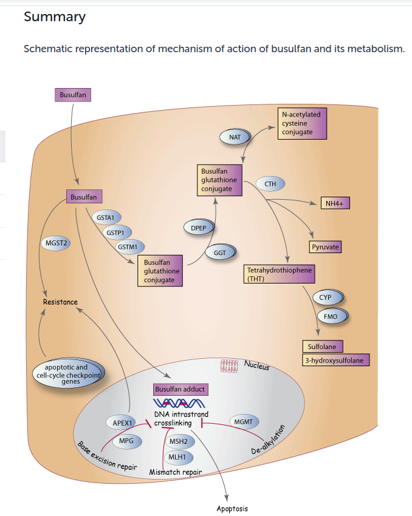

## DGIdb

url: http://dgidb.org

Drug-Gene Interaction Database의 약자로, 다양한 Drug-gene 정보를 다루는 데이터베이스를 통합한 데이터베이스이다. DrugBANK, OncoKB, CiViC, TTD, FDA 등 수많은 약물 데이터베이스를 통합하여 편리한 인터페이스로 사용자에게 Drug-Gene 정보를 주는 데이터베이스이다. 유전자, 혹은 약물 정보로 검색할 수 있으며, interaction에 대한 모든 문헌자료를 도출해주는 동시에 문헌의 양으로 점수화하는 시스템도 제공한다. 다운로드 탭에서 모든 상호작용에 대한 문헌정보 (PUBMED ID)를 다운받을 수 있다.

[figure not shown]

## LINCS

url: http://www.lincsproject.org

LINCS (Integrated Network Based Cellular Signatures) 프로그램 라이브러리는 세포가 다양한 매개체에 노출되었을 때 발생하는 유전자 발현 및 기타 세포 과정의 변화를 측정하여, 세포를 전사조절 네트워크 (transcription regulatory network) 기반으로 이해하는 것을 목표로 한다.

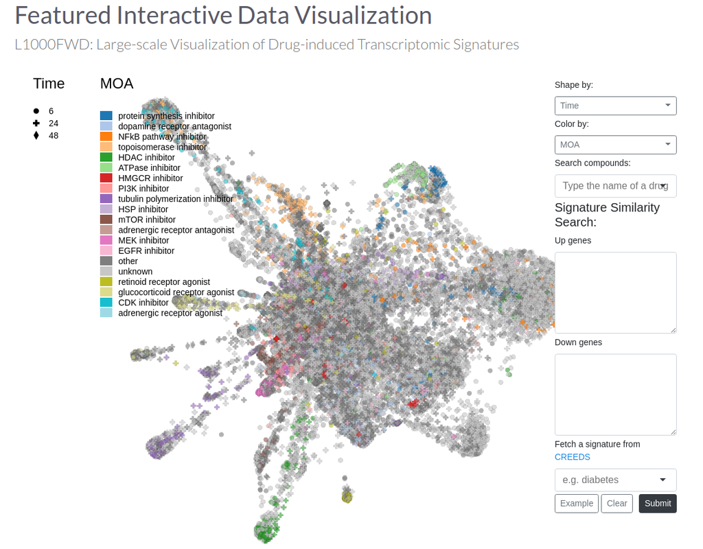

약물 처치 전, 후의 유전자 발현량을 측정한 CMAP 데이터베이스가 대표적이며, 현재 CLUE clue.io 에서 쿼리를 통해 정보를 제공한다.

[figure not shown]